# Conjugate Families

## Binomial Data Model

- It is observed that $Y=30$ of the $n=50$ polled voters support Michelle.
- We now want to find the likelihood function – remember that we treat $Y=30$ as the observed data and $\pi$ as unknown,

$$\begin{align*}
f(y|\pi) &= {50 \choose y} \pi^y (1-\pi)^{50-y} \\
L(\pi|y=30) &= {50 \choose 30} \pi^{30} (1-\pi)^{20}
\end{align*}$$

- This is valid for $\pi \in [0, 1]$.

## Binomial Data Model

- What is the likelihood of 30/50 voters supporting Michelle?

```r
dbinom(30, 50, pi)
```

- You try this for $\pi = \{0.25, 0.50, 0.75\}$.

```r
dbinom(30, 50, 0.25)
dbinom(30, 50, 0.5)
dbinom(30, 50, 0.75)
```

## Binomial Data Model

- What is the likelihood of 30/50 voters supporting Michelle?

```r
dbinom(30, 50, 0.25)
```

```
[1] 1.29633e-07
```

```r
dbinom(30, 50, 0.5)
```

```
[1] 0.04185915
```

```r
dbinom(30, 50, 0.75)
```

```
[1] 0.007654701
```

## Binomial Data Model

- Looking at $\pi$ in a more continuous fashion,

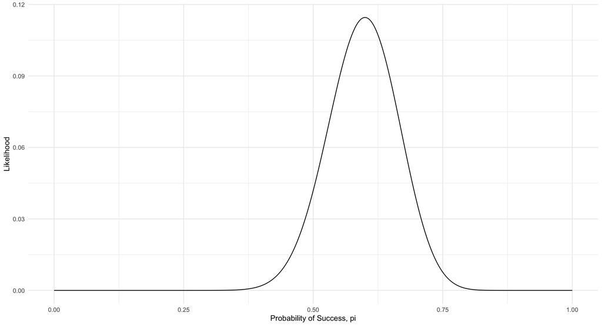

- Where is the maximum?

## Binomial Data Model

- Where is the maximum?

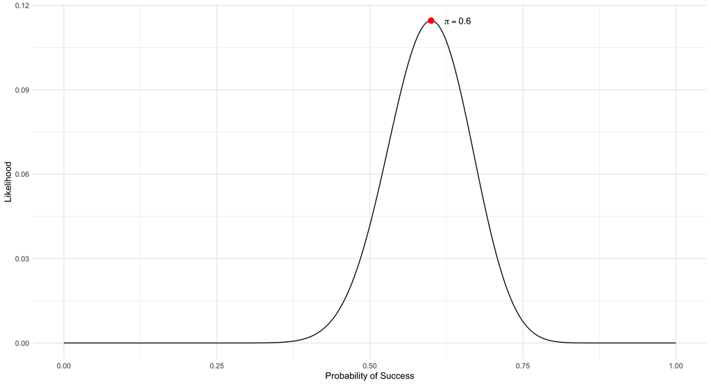

## The Beta Posterior Model

- The `plot_beta_binomial()` function:

```r
plot_beta_binomial(alpha = prior_alpha,
                   beta = prior_beta,
                   y = num_success,
                   n = num_trials,
                   posterior = TRUE or FALSE)
```

- The `summarize_beta_binomial()` function:

```r
summarize_beta_binomial(alpha = prior_alpha,
                        beta = prior_beta,
                        y = num_success,
                        n = num_trials)
```

## The Beta Posterior Model

- Looking at just the prior and the data distributions,

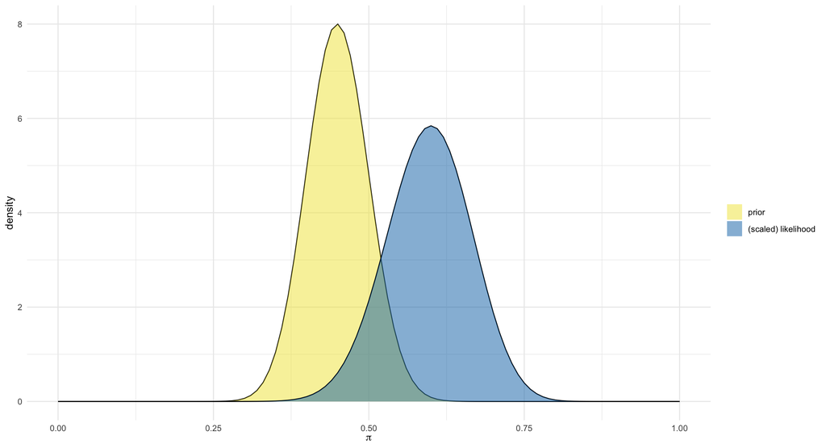

- The prior is a bit more pessimistic about Michelle’s election support than the data obtained from the latest poll.

## The Beta Posterior Model

- Now including the posterior,

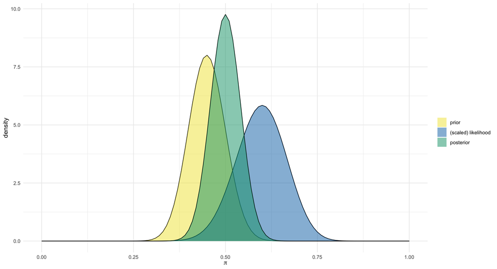

- We can see that the posterior model of $\pi$ is continuous and $\in [0, 1]$.
- The shape of the posterior appears to also have a Beta($\alpha$, $\beta$) model.
  - The shape parameters ($\alpha$ and $\beta$) have been *updated*.

## The Beta Posterior Model

- If we were to collect more information about Michelle’s support, we would use the current posterior as the new prior, then update our posterior.
  - How do we know what the updated parameters are?

```r
summarize_beta_binomial(alpha = 45, beta = 55, y = 30, n = 50)
```

| model | alpha | beta | mean | mode | var | sd |
| --- | --- | --- | --- | --- | --- | --- |
| prior | 45 | 55 | 0.45 | 0.4489796 | 0.0024505 | 0.0495025 |
| posterior | 75 | 75 | 0.50 | 0.5000000 | 0.0016556 | 0.0406894 |

## The Beta Posterior Model

- We used Michelle’s election support to understand the Beta-Binomial model.
- Let’s now generalize it for any appropriate situation.

$$\begin{align*}
Y|\pi &\sim \text{Bin}(n, \pi) \\
\pi &\sim \text{Beta}(\alpha, \beta) \\
\pi | (Y=y) &\sim \text{Beta}(\alpha+y, \beta+n-y)
\end{align*}$$

- We can see that the posterior distribution reveals the influence of the prior ($\alpha$ and $\beta$) and data ($y$ and $n$).

## The Beta Posterior Model

- Under this updated distribution,

$$\pi | (Y=y) \sim \text{Beta}(\alpha+y, \beta+n-y)$$

- we have updated moments:

$$\begin{align*}
E[\pi | Y = y] &= \frac{\alpha + y}{\alpha + \beta + n} \\
\text{Var}[\pi|Y=y] &= \frac{(\alpha+y)(\beta+n-y)}{(\alpha+\beta+n)^2(\alpha+\beta+n+1)}
\end{align*}$$

## The Beta Posterior Model

- Let’s pause and think about this from a theoretical standpoint.
- The Beta distribution is a *conjugate prior* for the likelihood.
  - **Conjugate prior**: the posterior is from the same model family as the prior.
- Recall the Beta prior, $f(\pi)$,

$$f(\pi) = \frac{\Gamma(\alpha+\beta)}{\Gamma(\alpha)\Gamma(\beta)} \pi^{\alpha-1}(1-\pi)^{\beta-1},$$

- and the likelihood function, $L(\pi|y)$,

$$L(\pi|y) = {n \choose y} \pi^y (1-\pi)^{n-y}$$

## The Beta Posterior Model

- We can put the prior and likelihood together to create the posterior,

$$\begin{align*}
f(\pi|y) &\propto f(\pi)L(\pi|y) \\
&= \frac{\Gamma(\alpha+\beta)}{\Gamma(\alpha)\Gamma(\beta)} \pi^{\alpha-1}(1-\pi)^{\beta-1} \times {n \choose y} \pi^y (1-\pi)^{n-y} \\
&\propto \pi^{(\alpha+y)-1} (1-\pi)^{(\beta+n-y)-1}
\end{align*}$$

- This is the same structure as the normalized Beta($\alpha+y, \beta+n-y$),

$$f(\pi|y) = \frac{\Gamma(\alpha+\beta+n)}{\Gamma(\alpha+y) \Gamma(\beta+n-y)} \pi^{(\alpha+y)-1} (1-\pi)^{(\beta+n-y)-1}$$

## Beta-Binomial: Example

- In Mario Kart 8 Deluxe, item boxes give different items depending on race position. To reduce the “position bias,” only item boxes opened while the racer was in mid-pack (positions 4–10) were recorded.
- You want to estimate the probability that an item box yields a Red Shell. When playing the Special Cup, only 31 red shells were seen in 114 boxes opened by mid-pack racers.
- Find the posterior distribution under two priors:
  1. Flat/uninformative prior, Beta(1,1).
  2. Beta($\alpha$, $\beta$) of your choosing.

## Wrap Up: Beta-Binomial Model

- We have built the Beta-Binomial model for $\pi$, an unknown proportion.

$$\begin{equation*}
\begin{aligned}
Y|\pi &\sim \text{Bin}(n,\pi) \\
\pi &\sim \text{Beta}(\alpha,\beta) &
\end{aligned}
\Rightarrow
\begin{aligned}
&& \pi | (Y=y) &\sim \text{Beta}(\alpha+y, \beta+n-y) \\
\end{aligned}
\end{equation*}$$

- The prior model, $f(\pi)$, is given by Beta($\alpha,\beta$).
- The data model, $f(Y|\pi)$, is given by Bin($n,\pi$).
- The likelihood function, $L(\pi|y)$, is obtained by plugging $y$ into the Binomial pmf.
- The posterior model is a Beta distribution with updated parameters $\alpha+y$ and $\beta+n-y$.

Take a break!

Back in 5 minutes.

## Introduction: Gamma-Poisson Model

- Recall the Beta-Binomial model,
  - $y \sim \text{Bin}(n, \pi)$ (data distribution)
  - $\pi \sim \text{Beta}(\alpha, \beta)$ (prior distribution)
  - $\pi|y \sim \text{Beta}(\alpha+y, \beta+n-y)$ (posterior distribution)
- Further recall that the Beta-Binomial model is from a *conjugate family*.
- Now, we will learn about the Gamma-Poisson, another conjugate family.

## Example Set Up

- Suppose we are now interested in modeling the number of spam calls we receive.
  - This means that we are modeling the rate, $\lambda$.
- We take a guess and say that the value of $\lambda$ that is most likely is around 5,
  - … but reasonably ranges between 2 and 7 calls per day.
- Why can’t we use the Beta distribution as our prior distribution?
  - $\lambda$ is the mean of a count $\to$ $\lambda \in \mathbb{R}^+$ $\to$ $\lambda$ is not limited to $[0, 1]$ $\to$ broken assumption for Beta distribution.
- Why can’t we use the binomial distribution as our data distribution?
  - $Y_i$ is a count $\to$ $Y_i \in \mathbb{N}^+$ $\to$ $Y_i$ is not limited to $\{0, 1\}$ $\to$ broken assumption for Binomial distribution.

## Poisson Data Model

- We will use the Poisson distribution to model the number of spam calls, $Y \in \{0, 1, 2, ...\}$
  - $Y$ is the number of independent events that occur in a fixed amount of time or space.
  - $\lambda > 0$ is the rate at which these events occur.
- Mathematically,

$$Y | \lambda \sim \text{Pois}(\lambda),$$

- with pmf,

$$f(y|\lambda) = \frac{\lambda^y e^{-\lambda}}{y!}, \ \ \ y \in \{0,1, 2, ... \}$$

## Gamma Prior

- If $\lambda$ is a continuous, positive random variable ($\lambda > 0$), we will employ the Gamma distribution defined by shape hyperparameter $s$ ($s>0$) and rate hyperparameter ($r>0$),

$$\lambda \sim \text{Gamma}(s, r)$$

- The Gamma pdf is given by

$$f(\lambda) = \frac{r^s}{\Gamma(s)} \lambda^{s-1} e^{-r\lambda}$$

## Gamma Prior: Shapes

- Let’s explore the shape of the Gamma:

```r
plot_gamma(1, 1) + theme_minimal() + ggtitle("Gamma(1, 1)")
```

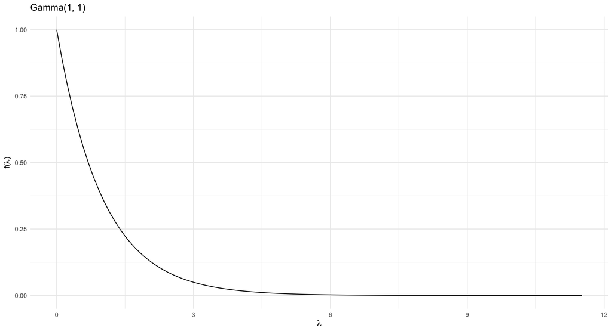

## Gamma Prior: Shapes

- Let’s explore the shape of the Gamma:

```r
plot_gamma(2, 1) + theme_minimal() + ggtitle("Gamma(2, 1)")
```

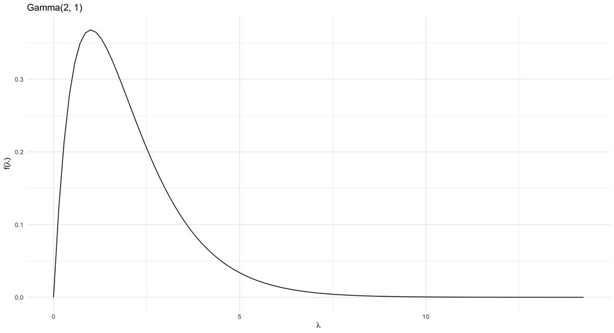

## Gamma Prior: Shapes

- Let’s explore the shape of the Gamma:

```r
plot_gamma(10, 1) + theme_minimal() + ggtitle("Gamma(10, 1)")
```

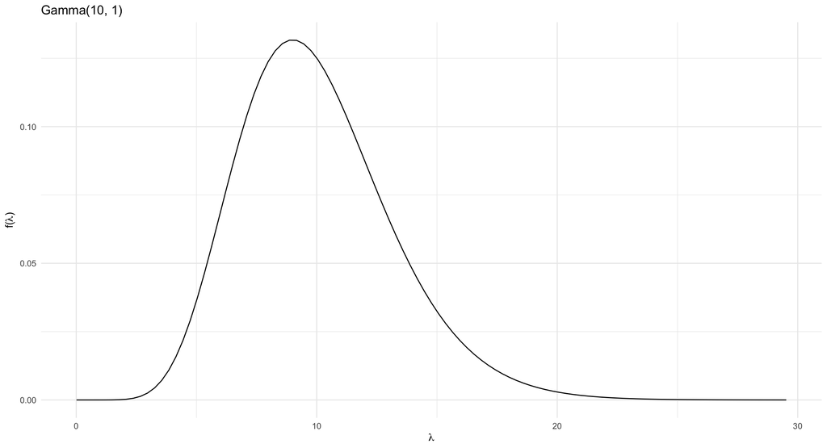

## Gamma Prior: Shapes

- Let’s explore the shape of the Gamma:

```r
plot_gamma(10, 10) + theme_minimal() + ggtitle("Gamma(10, 10)")
```

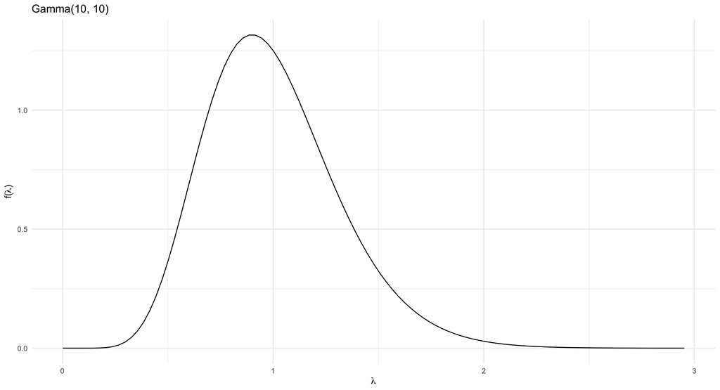

## Gamma Prior: Shapes

- What happens when we change hyperparameters $r$ and $s$?

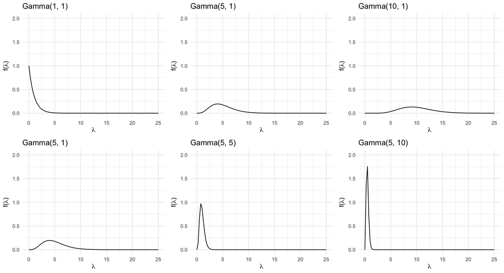

## Tuning the Gamma Prior

- Let’s now tune our prior assuming $\lambda \approx 5$.
- We know the mean of the gamma distribution,

$$E(\lambda) = \frac{s}{r} \approx 5 \to 5r \approx s$$

- Your turn! Use the `plot_gamma()` function to figure out what value of $s$ and $r$ we need.

## Tuning the Gamma Prior

- Looking at different values:

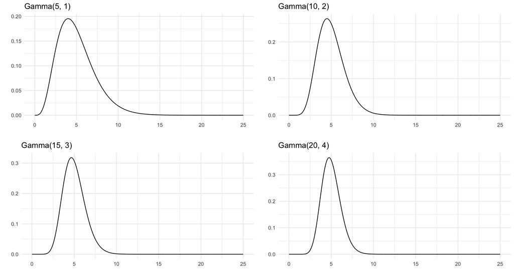

## Poisson Data Model

- We will be taking samples from different days.
  - Each day’s count is independently drawn from the same Poisson distribution. On each day $i$,

$$Y_i|\lambda \sim \text{Pois}(\lambda)$$

- This has a unique pmf for each day ($i$),

$$f(y_i|\lambda) = \frac{\lambda^{y_i} e^{-\lambda}}{y_i!}$$

- However, we are interested in the *joint* information in our sample of $n$ observations.

## Poisson Data Model

- The joint pmf for the Poisson,

$$\begin{align*}
f\left(\overset{\to}{y_i}|\lambda\right) &= \prod_{i=1}^n f(y_i|\lambda) \\
&= f(y_1|\lambda) \times f(y_2|\lambda) \times ... \times f(y_n|\lambda) \\
&= \frac{\lambda^{y_1}e^{-\lambda}}{y_1!} \times \frac{\lambda^{y_2}e^{-\lambda}}{y_2!} \times ... \times \frac{\lambda^{y_n}e^{-\lambda}}{y_n!} \\
&= \frac{\left( \lambda^{y_1} \lambda^{y_2} \cdot \cdot \cdot \ \lambda^{y_n} \right) \left( e^{-\lambda} e^{-\lambda} \cdot \cdot \cdot e^{-\lambda}\right)}{y_1! y_2! \cdot \cdot \cdot y_n!} \\
&= \frac{\lambda^{\sum y_i}e^{-n\lambda}}{\prod_{i=1}^n y_i !}
\end{align*}$$

## Poisson Data Model

- If the joint pmf for the Poisson is

$$f\left(\overset{\to}{y_i}|\lambda\right) = \frac{\lambda^{\sum y_i}e^{-n\lambda}}{\prod_{i=1}^n y_i !}$$

- then the likelihood function for $\lambda > 0$ is

$$\begin{align*}
L\left(\lambda|\overset{\to}{y_i}\right) &= \frac{\lambda^{\sum y_i}e^{-n\lambda}}{\prod_{i=1}^n y_i !} \\
& \propto \lambda^{\sum y_i} e^{-n\lambda}
\end{align*}$$

- Please see page 102 in Bayes Rules! for full derivations.

## Gamma-Poisson Conjugacy

- Let $\lambda > 0$ be an unknown *rate* parameter and $(Y_1, Y_2, ... , Y_n)$ be an independent sample from the Poisson distribution.
- The Gamma-Poisson Bayesian model is as follows:

$$\begin{align*}
Y_i | \lambda &\overset{\text{ind}}\sim \text{Poisson}(\lambda) \\
\lambda &\sim \text{Gamma}(s, r) \\
\lambda | \overset{\to}y &\sim \text{Gamma}\left( s + \sum y_i, r + n \right)
\end{align*}$$

- The proof can be seen in section 5.2.4 of Bayes Rules!

## Gamma-Poisson Conjugacy

- Suppose we use Gamma(10, 2) as the prior for $\lambda$, the daily rate of calls.
- On four separate days in the second week of August (i.e., independent days), we received $\overset{\to}y = (6, 2, 2, 1)$ calls.

```r
mean(c(6, 2, 2, 1))
```

```
[1] 2.75
```

- We can see that the average is around 2.75, which will inform the likelihood.

## Gamma-Poisson Conjugacy

- We know our prior distribution is Gamma(10, 2) and the data distribution is $\text{Poi}(\lambda)$, with observed sample mean $\bar{y} = 2.75$.
- Thus, the posterior is as follows,

$$\begin{align*}
\lambda | \overset{\to}y &\sim \text{Gamma}\left( s + \sum y_i, r + n \right) \\
&\sim \text{Gamma}\left(10 + 11, 2 + 4 \right) \\
&\sim \text{Gamma}\left(21, 6 \right)
\end{align*}$$

## The Gamma Posterior Model

- The `plot_gamma_poisson()` function:

```r
plot_gamma_poisson(shape = prior_s,
                   rate = prior_r,
                   sum_y = sum_of_obs,
                   n = sample_size,
                   posterior = TRUE or FALSE)
```

- The `summarize_gamma_poisson()` function:

```r
summarize_gamma_poisson(shape = prior_s,
                        rate = prior_r,
                        sum_y = sum_of_obs,
                        n = sample_size)
```

## The Gamma Posterior Model

- Looking at just the prior and the data distributions,

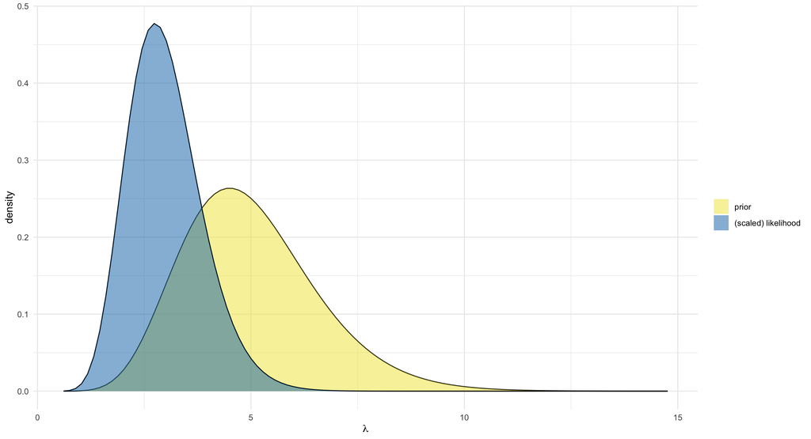

- The prior expects more spam calls than what we observed.

## The Gamma Posterior Model

- Now including the posterior,

```r
plot_gamma_poisson(shape = 10, rate = 2, sum_y = 11, n = 4, posterior = TRUE) + theme_minimal()
```

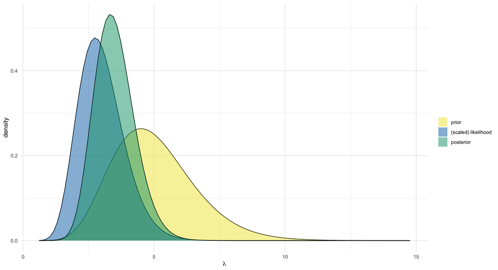

- The shape of the posterior has a Gamma($s$, $r$) model.
  - The shape and rate parameters ($s$ and $r$) have been *updated*.

## The Gamma Posterior Model

- Your turn! What is different if we had used one of the other priors?
- Recall, we considered
  - Gamma(5, 1)
  - Gamma(10, 2)
  - Gamma(15, 3)
  - Gamma(20, 4)

## The Gamma Posterior Model

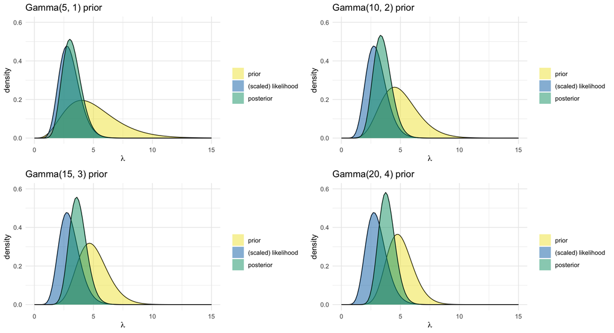

## The Gamma Posterior Model

```r
summarize_gamma_poisson(shape = 5, rate = 1,  sum_y = 11, n = 4)
```

| model | shape | rate | mean | mode | var | sd |
| --- | --- | --- | --- | --- | --- | --- |
| prior | 5 | 1 | 5.0 | 4 | 5.00 | 2.236068 |
| posterior | 16 | 5 | 3.2 | 3 | 0.64 | 0.800000 |

```r
summarize_gamma_poisson(shape = 10, rate = 2,  sum_y = 11, n = 4)
```

| model | shape | rate | mean | mode | var | sd |
| --- | --- | --- | --- | --- | --- | --- |
| prior | 10 | 2 | 5.0 | 4.500000 | 2.5000000 | 1.5811388 |
| posterior | 21 | 6 | 3.5 | 3.333333 | 0.5833333 | 0.7637626 |

```r
summarize_gamma_poisson(shape = 15, rate = 3,  sum_y = 11, n = 4)
```

| model | shape | rate | mean | mode | var | sd |
| --- | --- | --- | --- | --- | --- | --- |
| prior | 15 | 3 | 5.000000 | 4.666667 | 1.6666667 | 1.2909944 |
| posterior | 26 | 7 | 3.714286 | 3.571429 | 0.5306122 | 0.7284314 |

```r
summarize_gamma_poisson(shape = 20, rate = 4,  sum_y = 11, n = 4)
```

| model | shape | rate | mean | mode | var | sd |
| --- | --- | --- | --- | --- | --- | --- |
| prior | 20 | 4 | 5.000 | 4.75 | 1.250000 | 1.1180340 |
| posterior | 31 | 8 | 3.875 | 3.75 | 0.484375 | 0.6959705 |

## Wrap Up: Gamma-Poisson Model

- We have built the Gamma-Poisson model for $\lambda$, an unknown rate.

$$\begin{equation*}
\begin{aligned}
Y|\lambda &\sim \text{Poi}(\lambda) \\
\lambda &\sim \text{Gamma}(s, r) &
\end{aligned}
\Rightarrow
\begin{aligned}
&& \lambda | y &\sim \text{Gamma}(s + \sum y_i, r + n) \\
\end{aligned}
\end{equation*}$$

- The prior model, $f(\lambda)$, is given by Gamma($s, r$).
- The data model, $f(Y|\lambda)$, is given by Poi($\lambda$).
- The posterior model is a Gamma distribution with updated parameters $s+\sum y_i$ and $r + n$.

Take a break!

Back in 5 minutes.

## Introduction: Normal-Normal Model

- We have so far learned two conjugate families:
  - Beta-Binomial (binary outcomes)
    - $y \sim \text{Bin}(n, \pi)$ (data distribution)
    - $\pi \sim \text{Beta}(\alpha, \beta)$ (prior distribution)
    - $\pi|y \sim \text{Beta}(\alpha+y, \beta+n-y)$ (posterior distribution)
  - Gamma-Poisson (count outcomes)
    - $Y_i | \lambda \overset{ind}\sim \text{Pois}(\lambda)$ (data distribution)
    - $\lambda \sim \text{Gamma}(s, r)$ (prior distribution)
    - $\lambda | \overset{\to}y \sim \text{Gamma}\left( s + \sum y_i, r + n \right)$ (posterior distribution)
- Now, we will learn about another conjugate family, the Normal-Normal, for continuous outcomes.

## Example Set Up

- As scientists learn more about brain health, the dangers of concussions are gaining greater attention.
- We are interested in $\mu$, the average volume (cm<sup>3</sup>) of a specific part of the brain: the hippocampus.
- [Wikipedia](https://en.wikipedia.org/wiki/Hippocampus#Other_mammals) tells us that among the general population of human adults, each half of the hippocampus has volume between 3.0 and 3.5 cm<sup>3</sup>.
  - Total hippocampal volume of both sides of the brain is between 6 and 7 cm<sup>3</sup>.
  - Let’s assume that the mean hippocampal volume among people with a history of concussions is also somewhere between 6 and 7 cm<sup>3</sup>.
- We will take a sample of $n=25$ participants and update our belief.

## The Normal Model

- Let $Y \in \mathbb{R}$ be a continuous random variable.
  - The variability in $Y$ may be represented with a Normal model with mean parameter $\mu \in \mathbb{R}$ and standard deviation parameter $\sigma > 0$.
- The Normal model’s pdf is as follows,

$$f(y) = \frac{1}{\sqrt{2\pi\sigma^2}} \exp \left\{ \frac{-(y-\mu)^2}{2\sigma^2} \right\}$$

## The Normal Model

- If we vary $\mu$,

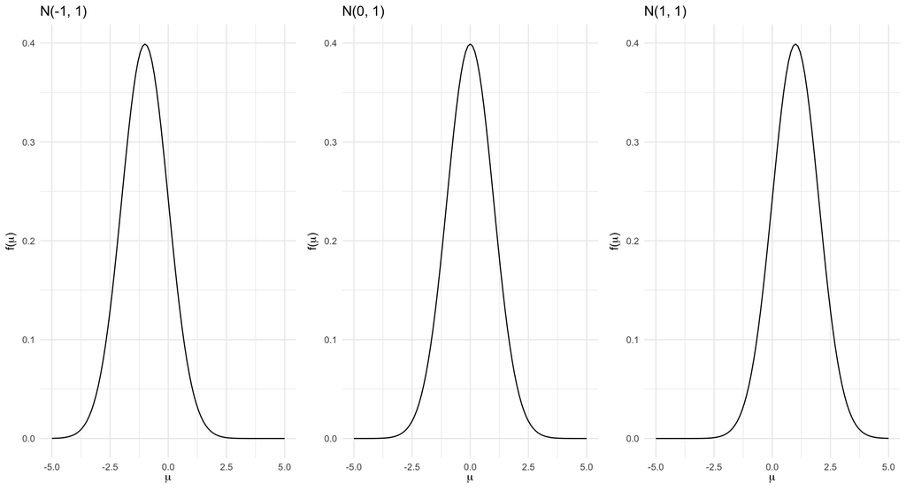

## The Normal Model

- If we vary $\sigma$,

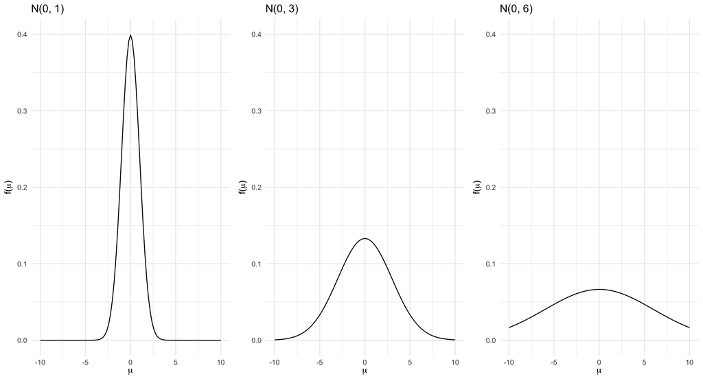

## The Normal Model

- Our data model is as follows,

$$Y_i | \mu \sim N(\mu, \sigma^2)$$

- The joint pdf is as follows,

$$f(\overset{\to}y | \mu) = \prod_{i=1}^n f(y_i | \mu) = \prod_{i=1}^n \frac{1}{\sqrt{2 \pi \sigma^2}} \exp \left\{ \frac{-(y_i-\mu)^2}{2\sigma^2} \right\}$$

## The Normal Model

- And the likelihood is as follows,

$$L(\mu|\overset{\to}y) \propto \prod_{i=1}^n \frac{1}{\sqrt{2 \pi \sigma^2}} \exp \left\{ \frac{-(y_i-\mu)^2}{2\sigma^2} \right\} = \exp \left\{ \frac{- \sum_{i=1}^n(y_i-\mu)^2}{2\sigma^2} \right\}$$

## The Normal Model

- Our data model is as follows,

$$Y_i | \mu \sim N(\mu, \sigma^2)$$

- Returning to our brain analysis, we will assume that the hippocampal volumes of our $n = 25$ subjects have a normal distribution with mean $\mu$ and standard deviation $\sigma$.
  - Right now, we are only interested in $\mu$, so we assume $\sigma = 0.5$ cm<sup>3</sup>
  - This choice suggests that most people have hippocampal volumes within $2 \sigma = 1$ cm<sup>3</sup>.

## Normal Prior

- We know that with $Y_i | \mu \sim N(\mu, \sigma^2)$, $\mu \in \mathbb{R}$.
  - We think a normal prior for $\mu$ is reasonable.
- Thus, we assume that $\mu$ has a normal distribution around some mean, $\theta$, with standard deviation, $\tau$.

$$\mu \sim N(\theta, \tau^2)$$

- meaning that $\mu$ has prior pdf

$$f(\mu) = \frac{1}{\sqrt{2 \pi \tau^2}} \exp \left\{ \frac{-(\mu - \theta)^2}{2 \tau^2} \right\}$$

## Tuning the Normal Prior

- We can tune the hyperparameters $\theta$ and $\tau$ to reflect our understanding and uncertainty about the average hippocampal volume ($\mu$) among people with a history of concussions.
- Wikipedia showed us that hippocampal volumes tend to be between 6 and 7 cm<sup>3</sup> $\to$ $\theta=6.5$.
- When we set the standard deviation we can check the plausible range of values of $\mu$:
  - Follow up: why 2?

$$\theta \pm 2 \times \tau$$

- If we assume $\tau=0.4$,

$$(6.5 \pm 2 \times 0.4) = (5.7, 7.3)$$

## Tuning the Normal Prior

- Thus, our tuned prior is $\mu \sim N(6.5, 0.4^2)$

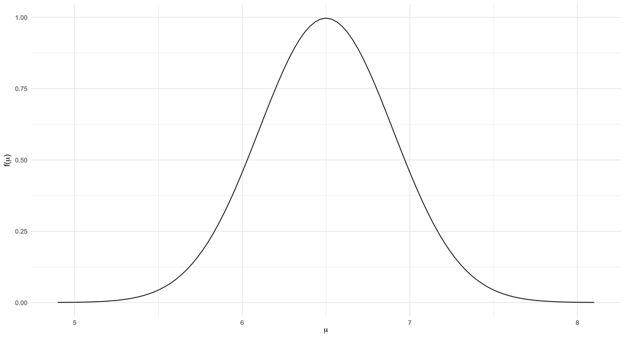

- This range incorporates our uncertainty - it is wider than the Wikipedia range.

## Normal-Normal Conjugacy

- Let $\mu \in \mathbb{R}$ be an unknown mean parameter and $(Y_1, Y_2, ..., Y_n)$ be an independent $N(\mu, \sigma^2)$ sample where $\sigma$ is assumed to be known.
- The Normal-Normal Bayesian model is as follows:

$$\begin{align*}
Y_i | \mu &\overset{\text{iid}} \sim N(\mu, \sigma^2) \\
\mu &\sim N(\theta, \tau^2) \\
\mu | \overset{\to}y &\sim N\left( \theta \frac{\sigma^2}{n\tau^2 + \sigma^2} + \bar{y} \frac{n\tau^2}{n\tau^2 + \sigma^2}, \frac{\tau^2 \sigma^2}{n \tau^2 + \sigma^2} \right)
\end{align*}$$

## Normal-Normal Conjugacy

- Let’s think about our posterior and some implications,

$$\mu | \overset{\to}y \sim N\left( \theta \frac{\sigma^2}{n\tau^2 + \sigma^2} + \bar{y} \frac{n\tau^2}{n\tau^2 + \sigma^2}, \frac{\tau^2 \sigma^2}{n \tau^2 + \sigma^2} \right)$$

- What happens as $n$ increases?

## Normal-Normal Conjugacy

- Let’s think about our posterior and some implications,

$$\mu | \overset{\to}y \sim N\left( \theta \frac{\sigma^2}{n\tau^2 + \sigma^2} + \bar{y} \frac{n\tau^2}{n\tau^2 + \sigma^2}, \frac{\tau^2 \sigma^2}{n \tau^2 + \sigma^2} \right)$$

- What happens as $n$ increases?

$$\begin{align*}
\frac{\sigma^2}{n\tau^2 + \sigma^2} &\to 0 \\
\frac{n\tau^2}{n\tau^2 + \sigma^2} &\to 1 \\
\frac{\tau^2 \sigma^2}{n \tau^2 + \sigma^2} &\to 0
\end{align*}$$

## Normal-Normal Conjugacy

- Let’s think about our posterior and some implications,

$$\begin{align*}
\frac{\sigma^2}{n\tau^2 + \sigma^2} &\to 0 \\
\frac{n\tau^2}{n\tau^2 + \sigma^2} &\to 1 \\
\frac{\tau^2 \sigma^2}{n \tau^2 + \sigma^2} &\to 0
\end{align*}$$

- The posterior mean places less weight on the prior mean and more weight on the sample mean $\bar{y}$.
- The posterior certainty about $\mu$ increases and becomes more in sync with the data.

## The Normal Posterior Model

- The `plot_normal_normal()` function:

```r
plot_normal_normal(mean = prior_mean,
                   sd = prior_sd,
                   sigma = data_sigma,
                   y_bar = sample_mean,
                   n = num_obs,
                   posterior = TRUE or FALSE)
```

- The `summarize_normal_normal()` function:

```r
summarize_normal_normal(mean = prior_mean,
                        sd = prior_sd,
                        sigma = data_sigma,
                        y_bar = sample_mean,
                        n = num_obs)
```

## The Normal Posterior Model

- Let us now apply this to our example.
- We have our prior model, $\mu \sim N(6.5, 0.4^2)$.
- Let’s look at the `football` dataset in the `bayesrules` package.

```r
data(football)
concussion_subjects <- football %>%
  filter(group == "fb_concuss")
```

- What is the average hippocampal volume?

## The Normal Posterior Model

- Let us now apply this to our example.
- We have our prior model, $\mu \sim N(6.5, 0.4^2)$.
- Let’s look at the `football` dataset in the `bayesrules` package.

```r
data(football)
concussion_subjects <- football %>%
  filter(group == "fb_concuss")
```

- What is the average hippocampal volume?

```r
mean(concussion_subjects$volume)
```

```
[1] 5.7346
```

## The Normal Posterior Model

- Before computing the posterior, let’s examine the distribution of observed hippocampal volumes.

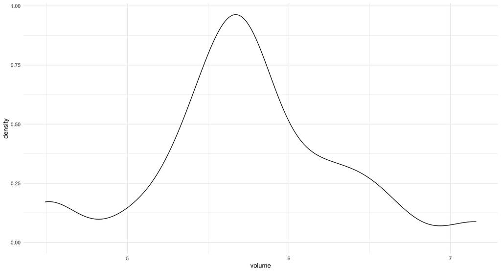

## The Normal Posterior Model

- Now, we can plug in the information we have ($n = 25, \bar{y} = 5.735, \sigma = 0.5$) into our likelihood,

$$L(\mu|\overset{\to}y) \propto \exp \left\{ \frac{-(5.735 - \mu)^2}{2(0.5^2/25)} \right\}$$

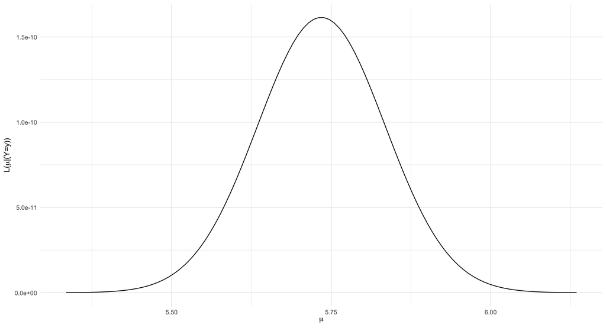

## The Normal Posterior Model

- We are now ready to put together our posterior:
  - Data distribution, $Y_i | \mu \overset{\text{iid}} \sim N(\mu, \sigma^2)$
  - Prior distribution, $\mu \sim N(\theta, \tau^2)$
  - Posterior distribution, $\mu | \overset{\to}y \sim N\left( \theta \frac{\sigma^2}{n\tau^2 + \sigma^2} + \bar{y} \frac{n\tau^2}{n\tau^2 + \sigma^2}, \frac{\tau^2 \sigma^2}{n \tau^2 + \sigma^2} \right)$
- Given our information ($\theta=6.5$, $\tau=0.4$, $n=25$, $\bar{y}=5.735$, $\sigma=0.5$), our posterior is

$$\mu | \overset{\to}y \sim N\left( \theta \frac{\sigma^2}{n\tau^2 + \sigma^2} + \bar{y} \frac{n\tau^2}{n\tau^2 + \sigma^2}, \frac{\tau^2 \sigma^2}{n \tau^2 + \sigma^2} \right)$$

## The Normal Posterior Model

- Given our information ($\theta=6.5$, $\tau=0.4$, $n=25$, $\bar{y}=5.735$, $\sigma=0.5$), our posterior is

$$\begin{align*}
\mu | \overset{\to}y &\sim N\left( \theta \frac{\sigma^2}{n\tau^2 + \sigma^2} + \bar{y} \frac{n\tau^2}{n\tau^2 + \sigma^2}, \frac{\tau^2 \sigma^2}{n \tau^2 + \sigma^2} \right) \\
&\sim N\left( 6.5 \frac{0.5^2}{25 \cdot 0.4^2 + 0.5^2} + 5.735 \frac{25 \cdot 0.4^2}{25 \cdot 0.4^2 + 0.5^2}, \frac{0.4^2 \cdot 0.5^2}{25 \cdot 0.4^2 + 0.5^2} \right) \\
&\sim N(6.5 \cdot 0.0588 + 5.735 \cdot 0.9412, 0.09^2) \\
&\sim N(5.78, 0.09^2)
\end{align*}$$

- Looking at the posterior, we can see the weights
  - 94% on the data mean, 6% on the prior mean.

## The Normal Posterior Model

- Looking at just the prior and data distributions,

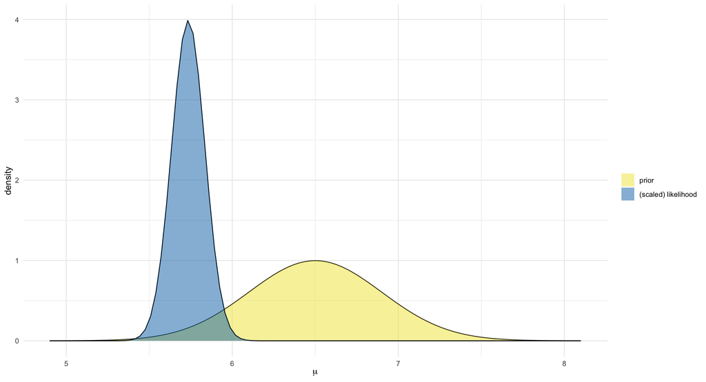

## The Normal Posterior Model

- Now including the posterior,

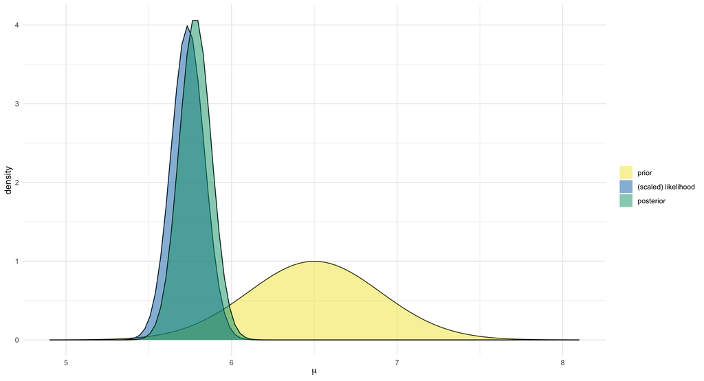

## The Normal Posterior Model

- We can use the `summarize_normal_normal()` function to summarize the distribution,

```r
summarize_normal_normal(mean = 6.5, sd = 0.4, sigma = 0.5, y_bar = 5.735, n = 25)
```

| model | mean | mode | var | sd |
| --- | --- | --- | --- | --- |
| prior | 6.50 | 6.50 | 0.1600000 | 0.4000000 |
| posterior | 5.78 | 5.78 | 0.0094118 | 0.0970143 |

## Wrap Up: Normal-Normal Model

- We have built the Normal-Normal model for $\mu$, an unknown mean.

$$\begin{equation*}
\begin{aligned}
Y_i | \mu &\overset{\text{iid}} \sim N(\mu, \sigma^2) \\
\mu &\sim N(\theta, \tau^2) &
\end{aligned}
\Rightarrow
\begin{aligned}
&& \mu | \overset{\to}y &\sim N\left( \theta \frac{\sigma^2}{n\tau^2 + \sigma^2} + \bar{y} \frac{n\tau^2}{n\tau^2 + \sigma^2}, \frac{\tau^2 \sigma^2}{n \tau^2 + \sigma^2} \right) \\
\end{aligned}
\end{equation*}$$

- The prior model, $f(\mu)$, is given by N($\theta,\tau^2$).
- The data model, $f(Y|\mu)$, is given by N($\mu, \sigma^2$).
- The posterior model is a Normal distribution with updated parameters
  - mean = $\theta \frac{\sigma^2}{n\tau^2 + \sigma^2} + \bar{y} \frac{n\tau^2}{n\tau^2 + \sigma^2}$
  - variance = $\frac{\tau^2 \sigma^2}{n \tau^2 + \sigma^2}$

## Wrap Up

- Today we covered the main *conjugate families*.
  - Beta-Binomial: binary outcomes
  - Gamma-Poisson: count outcomes
  - Normal-Normal: continuous outcomes
- You now are ready to work on Assignment 3: Conjugate Families.
  - .qmd file is available to download on Canvas.
- Wednesday: how do we actually draw conclusions using the posterior distribution?